# ufc-datacleaning

Ivan Aguilar Nieto and Alexander Holler Rodriguez

Junio

```r
knitr::opts_chunk$set(eval=T, echo=T)
library(ggplot2)
library(lessR)
library(dplyr)
library(convertr)
library(VIM)
library(corrplot)
library(nnet)
library(readr)
library(car)
```

# 1 Descripción de la actividad

## 1.1 Descripción

El objetivo de esta actividad será el tratamiento de un dataset para aprender a identificar los datos relevantes para un proyecto analítico y usar las herramientas de integración, limpieza, validación y análisis de las mismas.

## 1.2 Objetivos

Los objetivos que se persiguen mediante el desarrollo de esta actividad práctica son los siguientes: * Aprender a aplicar los conocimientos adquiridos y su capacidad de resolución de problemas en entornos nuevos o poco conocidos dentro de contextos más amplios o multidisciplinares. * Saber identificar los datos relevantes y los tratamientos necesarios (integración, limpieza y validación) para llevar a cabo un proyecto analítico. * Aprender a analizar los datos adecuadamente para abordar la información contenida en los datos. * Identificar la mejor representación de los resultados para aportar conclusiones sobre el problema planteado en el proceso analítico. * Actuar con los principios éticos y legales relacionados con la manipulación de datos en función del ámbito de aplicación. * Desarrollar las habilidades de aprendizaje que permita continuar estudiando de un modo que tendrá que ser en gran medida autodirigido o autónomo. * Desarrollar la capacidad de búsqueda, gestión y uso de información y recursos en el ámbito de la ciencia de datos.

## 1.3 Competencias

Así, las competencias del Máster en Data Science que se desarrollan son: * Capacidad de analizar un problema en el nivel de abstracción adecuado a cada situación y aplicar las habilidades y conocimientos adquiridos para abordarlo y resolverlo. * Capacidad para aplicar las técnicas específicas de tratamiento de datos (integración, transformación, limpieza y validación) para su posterior análisis.

# 2 Resolución de la actividad

## 2.1 Descripción del dataset

El conjunto de datos objeto de análisis se ha obtenido a partir de [este enlace](https://www.kaggle.com/calmdownkarm/ufcdataset) y está constituido por 894 variables (columnas) y 2318 registros (filas). Entre los campos de este conjunto de datos, nosotros utilizaremos los siguientes:

| Columna | Descripción |
| --- | --- |
| BPrev | Anteriores combates del luchador azul |
| BStreak | Racha de victorias del luchador azul |
| B_Age | Edad del luchador azul |
| B_Height | Altura del luchador azul |
| B_HomeTown | Ciudad natal del luchador azul |
| B_ID | Identificador del luchador azul |
| B_Location | Localización del luchador azul |
| B_Name | Nombre del luchador azul |
| B_Weight | Peso del luchador azul |
| Date | Fecha del combate |
| Event_ID | Identificador del evento |
| Fight_ID | Identificador del combate |
| Last_round | Última ronda |
| Max_round | Rondas máximas |
| RPrev | Anteriores combates del luchador rojo |
| R_Age | Edad del luchador rojo |
| R_Height | Altura del luchador rojo |
| R_HomeTown | Ciudad natal del luchador rojo |
| R_ID | Identificador del rojo |
| R_Location | Localización del rojo |
| R_Name | Nombre del luchador rojo |
| R_Weight | Peso del luchador rojo |
| winby | Motivo de ganar el combate |
| winner | Color del ganador del combate |

## 2.2 Importancia de los datos a analizar

A partir de este conjunto de datos veremos qué variables son más influyentes sobre el ganador de la pelea. Utilizando modelos de regresión podremos predecir el ganador de estas en función de sus características y contrastes de hipótesis que ayuden a identificar propiedades interesantes, donde estas puedan ser inferidas con respecto a la población.

Estos análisis han ganado mucho popularidad entre los espectadores, ya que cada vez son más aquellos que consumen este deporte mediante los medios de comunicación, por lo que, en lugares como casas de apuestas sería de gran interés poder predecir ciertos resultados de una pelea. No solo la casa de apuesta estaría interesado en estos resultados, sino todos aquellos que pretendan apostar.

## 2.3 Limpieza de los datos

```r
path <- "../data/ufc-in.csv"
ufc <- read_csv(path)
head(ufc)
```

```
## # A tibble: 6 x 894
##   BPrev BStreak B_Age B_Height B_HomeTown     B_ID B_Location   B_Name  B_Weight
##   <dbl>   <dbl> <dbl>    <dbl> <chr>         <dbl> <chr>        <chr>      <dbl>
## 1     0       0    38      193 Hounslow Eng…   808 Amsterdam T… Alista…      120
## 2     0       0    36      172 Chicago, Ill…  1054 Chicago, Il… Ricard…       65
## 3     0       0    39      167 Isla Vista ,…   959 Sacramento,… Urijah…       61
## 4     0       0    33      167 San Diego, C…  1056 San Diego, … Danny …       56
## 5     0       0    36      185 Southampton …  2005 Southampton… Tom Wa…       84
## 6     0       0    35      180 Amazonas Bra…  2101 Rio de Jane… Alan P…       70
## # … with 885 more variables: B__Round1_Grappling_Reversals_Landed <dbl>,
## #   B__Round1_Grappling_Standups_Landed <dbl>,
## #   B__Round1_Grappling_Submissions_Attempts <dbl>,
## #   B__Round1_Grappling_Takedowns_Attempts <dbl>,
## #   B__Round1_Grappling_Takedowns_Landed <dbl>,
## #   B__Round1_Strikes_Body Significant Strikes_Attempts <dbl>,
## #   B__Round1_Strikes_Body Significant Strikes_Landed <dbl>,
## #   B__Round1_Strikes_Body Total Strikes_Attempts <dbl>,
## #   B__Round1_Strikes_Body Total Strikes_Landed <dbl>,
## #   B__Round1_Strikes_Clinch Body Strikes_Attempts <dbl>,
## #   B__Round1_Strikes_Clinch Body Strikes_Landed <dbl>,
## #   B__Round1_Strikes_Clinch Head Strikes_Attempts <dbl>,
## #   B__Round1_Strikes_Clinch Head Strikes_Landed <dbl>,
## #   B__Round1_Strikes_Clinch Leg Strikes_Attempts <dbl>,
## #   B__Round1_Strikes_Clinch Leg Strikes_Landed <dbl>,
## #   B__Round1_Strikes_Clinch Significant Kicks_Attempts <dbl>,
## #   B__Round1_Strikes_Clinch Significant Kicks_Landed <dbl>,
## #   B__Round1_Strikes_Clinch Significant Punches_Attempts <dbl>,
## #   B__Round1_Strikes_Clinch Significant Punches_Landed <dbl>,
## #   B__Round1_Strikes_Clinch Significant Strikes_Attempts <dbl>,
## #   B__Round1_Strikes_Clinch Significant Strikes_Landed <dbl>,
## #   B__Round1_Strikes_Clinch Total Strikes_Attempts <dbl>,
## #   B__Round1_Strikes_Clinch Total Strikes_Landed <dbl>,
## #   B__Round1_Strikes_Distance Body Kicks_Attempts <dbl>,
## #   B__Round1_Strikes_Distance Body Kicks_Landed <dbl>,
## #   B__Round1_Strikes_Distance Body Punches_Attempts <dbl>,
## #   B__Round1_Strikes_Distance Body Punches_Landed <dbl>,
## #   B__Round1_Strikes_Distance Body Strikes_Attempts <dbl>,
## #   B__Round1_Strikes_Distance Body Strikes_Landed <dbl>,
## #   B__Round1_Strikes_Distance Head Kicks_Attempts <dbl>,
## #   B__Round1_Strikes_Distance Head Kicks_Landed <dbl>,
```

[output cut: 49 more lines]

```
## #   B__Round1_TIP_Mount Control Time <dbl>, B__Round1_TIP_Neutral Time <dbl>,
## #   B__Round1_TIP_Side Control Time <dbl>, B__Round1_TIP_Standing Time <dbl>,
## #   B__Round2_Grappling_Reversals_Landed <dbl>,
## #   B__Round2_Grappling_Standups_Landed <dbl>,
## #   B__Round2_Grappling_Submissions_Attempts <dbl>,
## #   B__Round2_Grappling_Takedowns_Attempts <dbl>,
## #   B__Round2_Grappling_Takedowns_Landed <dbl>,
## #   B__Round2_Strikes_Body Significant Strikes_Attempts <dbl>,
## #   B__Round2_Strikes_Body Significant Strikes_Landed <dbl>,
## #   B__Round2_Strikes_Body Total Strikes_Attempts <dbl>,
## #   B__Round2_Strikes_Body Total Strikes_Landed <dbl>,
## #   B__Round2_Strikes_Clinch Body Strikes_Attempts <dbl>,
## #   B__Round2_Strikes_Clinch Body Strikes_Landed <dbl>,
## #   B__Round2_Strikes_Clinch Head Strikes_Attempts <dbl>,
## #   B__Round2_Strikes_Clinch Head Strikes_Landed <dbl>, …
```

### 2.3.1 Selección de los datos de interés

Como podemos ver, se han cargado las 894 columnas comentadas al principio, pero como hemos dicho, para este caso solo utilizaremos 24, por lo que el primer paso será eliminar aquellas columnas que no necesitamos.

```r
dim(ufc)
```

```
## [1] 2318  894
```

Esto es debido a que mucha de la información presente en el dataset original no nos otorga información sobre el ganador, sino del transcurso detallado de cada pelea, como por ejemplo: Cuántos ganchos han habido en el primer round.

Es por ello que nosotros seleccionamos los datos más relevantes para nuestro objetivo.

```r
columnas_interes<-c('BPrev', 'BStreak', 'B_Age', 'B_Height', 'B_HomeTown', 'B_ID', 'B_Location', 'B_Name', 'B_Weight', 'Date', 'Event_ID', 'Fight_ID', 'Last_round', 'Max_round', 'RPrev', 'R_Age', 'R_Height', 'R_HomeTown', 'R_ID', 'R_Location', 'R_Name', 'R_Weight', 'winby', 'winner' )

ufc<-ufc[,columnas_interes]
summary(ufc)
```

```
##      BPrev           BStreak            B_Age          B_Height
##  Min.   : 0.000   Min.   : 0.0000   Min.   :20.00   Min.   :152.0
##  1st Qu.: 0.000   1st Qu.: 0.0000   1st Qu.:29.00   1st Qu.:172.0
##  Median : 2.000   Median : 0.0000   Median :31.00   Median :177.0
##  Mean   : 2.391   Mean   : 0.7446   Mean   :31.78   Mean   :177.3
##  3rd Qu.: 4.000   3rd Qu.: 1.0000   3rd Qu.:35.00   3rd Qu.:182.0
##  Max.   :14.000   Max.   :10.0000   Max.   :48.00   Max.   :213.0
##                                     NA's   :17      NA's   :17
##   B_HomeTown             B_ID       B_Location           B_Name
##  Length:2318        Min.   : 129   Length:2318        Length:2318
##  Class :character   1st Qu.:1910   Class :character   Class :character
##  Mode  :character   Median :2230   Mode  :character   Mode  :character
##                     Mean   :2120
##                     3rd Qu.:2709
##                     Max.   :3196
##
##     B_Weight         Date              Event_ID        Fight_ID
##  Min.   : 52.0   Length:2318        Min.   :646.0   Min.   :4521
##  1st Qu.: 61.0   Class :character   1st Qu.:703.0   1st Qu.:5240
##  Median : 70.0   Mode  :character   Median :775.0   Median :6078
##  Mean   : 73.7                      Mean   :769.5   Mean   :6015
##  3rd Qu.: 84.0                      3rd Qu.:828.0   3rd Qu.:6749
##  Max.   :120.0                      Max.   :887.0   Max.   :7508
##  NA's   :12
##    Last_round      Max_round         RPrev            R_Age
##  Min.   :1.000   Min.   :3.000   Min.   : 0.000   Min.   :20.00
##  1st Qu.:1.000   1st Qu.:3.000   1st Qu.: 1.000   1st Qu.:29.00
##  Median :3.000   Median :3.000   Median : 2.000   Median :32.00
##  Mean   :2.408   Mean   :3.195   Mean   : 3.031   Mean   :32.45
##  3rd Qu.:3.000   3rd Qu.:3.000   3rd Qu.: 5.000   3rd Qu.:35.00
##  Max.   :5.000   Max.   :5.000   Max.   :16.000   Max.   :48.00
##                                                   NA's   :26
##     R_Height      R_HomeTown             R_ID       R_Location
##  Min.   :152.0   Length:2318        Min.   : 129   Length:2318
##  1st Qu.:170.0   Class :character   1st Qu.:1494   Class :character
##  Median :177.0   Mode  :character   Median :2082   Mode  :character
##  Mean   :177.1                      Mean   :1904
##  3rd Qu.:185.0                      3rd Qu.:2344
##  Max.   :213.0                      Max.   :3194
##  NA's   :24
##     R_Name             R_Weight         winby              winner
##  Length:2318        Min.   : 52.00   Length:2318        Length:2318
##  Class :character   1st Qu.: 61.00   Class :character   Class :character
##  Mode  :character   Median : 70.00   Mode  :character   Mode  :character
##                     Mean   : 73.84
##                     3rd Qu.: 84.00
##                     Max.   :120.00
##                     NA's   :22
```

Tras eliminar las columnas que no vamos a usar, obtenemos estas 24 en la misma variable *ufc*.

### 2.3.2 Ceros y elementos vacíos

Una vez hemos seleccionado las columnas de interés, vemos a revisar si hay elementos vacíos.

```r
colSums(is.na(ufc) | ufc=="")
```

```
##      BPrev    BStreak      B_Age   B_Height B_HomeTown       B_ID B_Location
##          0          0         17         17         17          0         13
##     B_Name   B_Weight       Date   Event_ID   Fight_ID Last_round  Max_round
##          0         12          0          0          0          0          0
##      RPrev      R_Age   R_Height R_HomeTown       R_ID R_Location     R_Name
##          0         26         24         25          0         24          0
##   R_Weight      winby     winner
##         22         36          0
```

Nos encontramos con el siguiente número de valores vacíos: * Edad del luchador azul: 17 * Altura del luchador azul: 17 * Ciudad natal del luchador azul: 17 * Localización del luchador azul: 13 * Peso del luchador azul: 12 * Edad del luchador rojo: 26 * Altura del luchador rojo: 24 * Ciudad natal del luchador rojo: 25 * Localización del luchador rojo: 24 * Peso del luchador rojo: 22 * Motivo de la victoria: 36

Ahora, deberemos decidir como vamos a tratar estos valores, si vamos a intentar completarlos, los obviaremos, los eliminaremos, …

Para ello utilizaremos el método kNN, donde se imputan valores basado en la similitud o diferencia entre los registros. Predecir los valores, si no es suficientemente preciso, puede conllevar problemas a la hora de utilizarlos más adelante para predecir, pero su perdida es una consecuencia mucho peor.

Antes, para tener un punto de referencia, vamos a imprimir aquellos que *B_Location* sea null y veremos como se comporta el primer registro tras aplicar el método kNN

```r
head(ufc[is.na(ufc$B_Location),])
```

```
## # A tibble: 6 x 24
##   BPrev BStreak B_Age B_Height B_HomeTown  B_ID B_Location B_Name B_Weight Date
##   <dbl>   <dbl> <dbl>    <dbl> <chr>      <dbl> <chr>      <chr>     <dbl> <chr>
## 1     0       0    NA       NA <NA>        2179 <NA>       Lipen…       NA 03/0…
## 2     0       0    NA       NA <NA>        2246 <NA>       Anton…       NA 06/0…
## 3     1       1    NA       NA <NA>        2155 <NA>       Aleks…       NA 10/0…
## 4     1       1    NA       NA <NA>        2017 <NA>       Cat Z…       NA 03/0…
## 5     1       0    NA       NA <NA>        2298 <NA>       Yao Z…       NA 05/1…
## 6     0       0    30      175 Bydgoszcz…  2727 <NA>       Marci…       70 12/1…
## # … with 14 more variables: Event_ID <dbl>, Fight_ID <dbl>, Last_round <dbl>,
## #   Max_round <dbl>, RPrev <dbl>, R_Age <dbl>, R_Height <dbl>,
## #   R_HomeTown <chr>, R_ID <dbl>, R_Location <chr>, R_Name <chr>,
## #   R_Weight <dbl>, winby <chr>, winner <chr>
```

```r
ufc$B_Age <- kNN(ufc)$B_Age
ufc$B_Height <- kNN(ufc)$B_Height
ufc$B_HomeTown <- kNN(ufc)$B_HomeTown
ufc$B_Location <- kNN(ufc)$B_Location
ufc$B_Weight <- kNN(ufc)$B_Weight
ufc$R_Age <- kNN(ufc)$R_Age
ufc$R_Height <- kNN(ufc)$R_Height
ufc$R_HomeTown <- kNN(ufc)$R_HomeTown
ufc$R_Location <- kNN(ufc)$R_Location
ufc$R_Weight <- kNN(ufc)$R_Weight
ufc$winby <- kNN(ufc)$winby

colSums(is.na(ufc) | ufc=="")
```

```
##      BPrev    BStreak      B_Age   B_Height B_HomeTown       B_ID B_Location
##          0          0          0          0          0          0          0
##     B_Name   B_Weight       Date   Event_ID   Fight_ID Last_round  Max_round
##          0          0          0          0          0          0          0
##      RPrev      R_Age   R_Height R_HomeTown       R_ID R_Location     R_Name
##          0          0          0          0          0          0          0
##   R_Weight      winby     winner
##          0          0          0
```

Aunque nuestro dataset ha rellenado los valores de las columnas vacias con valores predecidos hay una columna que volveremos a rellenar con valores nuevos, ya que es una casuistica que no se podria predecir.

```r
ufc[ufc$winner=='draw' | ufc$winner=='no contest',c('winby', 'winner')]
```

```
## # A tibble: 40 x 2
##    winby  winner
##    <chr>  <chr>
##  1 SUB    no contest
##  2 DEC    no contest
##  3 DEC    draw
##  4 SUB    no contest
##  5 SUB    no contest
##  6 KO/TKO no contest
##  7 SUB    no contest
##  8 SUB    no contest
##  9 DEC    no contest
## 10 SUB    no contest
## # … with 30 more rows
```

```r
ufc$winby<-ifelse(ufc$winner=='draw', 'DRAW',
                  ifelse(ufc$winner=='no contest',"NO CONTEST",
                           ufc$winby))
ufc[ufc$winner=='draw' | ufc$winner=='no contest',c('winby', 'winner')]
```

```
## # A tibble: 40 x 2
##    winby      winner
##    <chr>      <chr>
##  1 NO CONTEST no contest
##  2 NO CONTEST no contest
##  3 DRAW       draw
##  4 NO CONTEST no contest
##  5 NO CONTEST no contest
##  6 NO CONTEST no contest
##  7 NO CONTEST no contest
##  8 NO CONTEST no contest
##  9 NO CONTEST no contest
## 10 NO CONTEST no contest
## # … with 30 more rows
```

Vemos que tras aplicarlo no hay ningún valor vacío, vamos ahora a ver como se ha comportado con nuestro sujeto.

```r
ufc[ufc$B_Name=="Lipeng Zhang",]
```

```
## # A tibble: 1 x 24
##   BPrev BStreak B_Age B_Height B_HomeTown  B_ID B_Location B_Name B_Weight Date
##   <dbl>   <dbl> <dbl>    <dbl> <chr>      <dbl> <chr>      <chr>     <dbl> <chr>
## 1     0       0    31      182 Santiago …  2179 Alagir Ru… Lipen…       77 03/0…
## # … with 14 more variables: Event_ID <dbl>, Fight_ID <dbl>, Last_round <dbl>,
## #   Max_round <dbl>, RPrev <dbl>, R_Age <dbl>, R_Height <dbl>,
## #   R_HomeTown <chr>, R_ID <dbl>, R_Location <chr>, R_Name <chr>,
## #   R_Weight <dbl>, winby <chr>, winner <chr>
```

### 2.3.3 La edad es estatica

Tras revisar la edad de los peleadores, nos hemos percatado que la edad de estos es estatica, es decir: Aunque un jugador juegue dos años distintos, vemos que su edad es la misma los dos años.

Para hacerlo, miraremos el caso del peleador *Jose Aldo*

```r
edad_jugador <-function(birthday){
  return(trunc((as.Date("01/01/2017",
                        "%m/%d/%Y")-as.Date(birthday,"%m/%d/%Y"))/365))
}
ufc[ufc$R_Name=='Jose Aldo',c('R_Name', 'R_Age', 'Date')]
```

```
## # A tibble: 6 x 3
##   R_Name    R_Age Date
##   <chr>     <dbl> <chr>
## 1 Jose Aldo    32 02/03/2014
## 2 Jose Aldo    32 10/27/2014
## 3 Jose Aldo    32 12/14/2015
## 4 Jose Aldo    32 07/11/2016
## 5 Jose Aldo    32 06/05/2017
## 6 Jose Aldo    32 07/30/2018
```

Como podemos ver, este peleador tiene 32 años en el año 2014 y también en el 2018, 4 años después. Para resolver esto tras una búsqueda en Google, sabemos que *Jose Aldo* en 2018 tenia 32, así que interpretaremos que la edad más actual es la de referencia. Pero primero de todo, hay fechas en formato Europeo y formato Americano, así que las pasaremos todas a Europeo.

```r
ufc$Date<-ifelse(grepl('-', ufc$Date),
       paste(substr(ufc$Date, 9, 11),'/',substr(ufc$Date, 6, 7),'/',substr(ufc$Date, 0, 4), sep=""),
       ufc$Date)
head(ufc)
```

```
## # A tibble: 6 x 24
##   BPrev BStreak B_Age B_Height B_HomeTown  B_ID B_Location B_Name B_Weight Date
##   <dbl>   <dbl> <dbl>    <dbl> <chr>      <dbl> <chr>      <chr>     <dbl> <chr>
## 1     0       0    38      193 Hounslow …   808 Amsterdam… Alist…      120 02/0…
## 2     0       0    36      172 Chicago, …  1054 Chicago, … Ricar…       65 02/0…
## 3     0       0    39      167 Isla Vist…   959 Sacrament… Urija…       61 02/0…
## 4     0       0    33      167 San Diego…  1056 San Diego… Danny…       56 02/0…
## 5     0       0    36      185 Southampt…  2005 Southampt… Tom W…       84 02/0…
## 6     0       0    35      180 Amazonas …  2101 Rio de Ja… Alan …       70 02/0…
## # … with 14 more variables: Event_ID <dbl>, Fight_ID <dbl>, Last_round <dbl>,
## #   Max_round <dbl>, RPrev <dbl>, R_Age <dbl>, R_Height <dbl>,
## #   R_HomeTown <chr>, R_ID <dbl>, R_Location <chr>, R_Name <chr>,
## #   R_Weight <dbl>, winby <chr>, winner <chr>
```

Tras ello, vamos a proseguir corrigiendo la edad de los luchadores. El procedimiento será restar la edad que figura en el registro a la resta del año del ultimo combate con el año del combate del registro.

Para ello, vamos a crear una columna con el año del combate

```r
ufc$year <- as.numeric(substring(ufc$Date,7,10))
head(ufc)
```

```
## # A tibble: 6 x 25
##   BPrev BStreak B_Age B_Height B_HomeTown  B_ID B_Location B_Name B_Weight Date
##   <dbl>   <dbl> <dbl>    <dbl> <chr>      <dbl> <chr>      <chr>     <dbl> <chr>
## 1     0       0    38      193 Hounslow …   808 Amsterdam… Alist…      120 02/0…
## 2     0       0    36      172 Chicago, …  1054 Chicago, … Ricar…       65 02/0…
## 3     0       0    39      167 Isla Vist…   959 Sacrament… Urija…       61 02/0…
## 4     0       0    33      167 San Diego…  1056 San Diego… Danny…       56 02/0…
## 5     0       0    36      185 Southampt…  2005 Southampt… Tom W…       84 02/0…
## 6     0       0    35      180 Amazonas …  2101 Rio de Ja… Alan …       70 02/0…
## # … with 15 more variables: Event_ID <dbl>, Fight_ID <dbl>, Last_round <dbl>,
## #   Max_round <dbl>, RPrev <dbl>, R_Age <dbl>, R_Height <dbl>,
## #   R_HomeTown <chr>, R_ID <dbl>, R_Location <chr>, R_Name <chr>,
## #   R_Weight <dbl>, winby <chr>, winner <chr>, year <dbl>
```

Primero creamos un dataset utilizando un método parecido al group by que agrupe por nombre del peleador y seleccione el del año mayor.

```r
max_years_r<-merge(ufc, aggregate(year ~ R_Name, ufc, max))
max_years_b<-merge(ufc, aggregate(year ~ B_Name, ufc, max))
```

```r
max_year_b<-array(numeric(),c(1,3,0))
max_year_r<-array(numeric(),c(1,3,0))

for(i in 1:nrow(ufc)) {
    # Blue
    mb<-head(max_years_b[max_years_b$B_Name==ufc[i,]$B_Name,],1)
    max_year_b[i]<-mb$year

    # Red
    mr<-head(max_years_r[max_years_r$R_Name==ufc[i,]$R_Name,],1)
    max_year_r[i]<-mr$year
}

ufc$max_year_b<-max_year_b
ufc$max_year_r<-max_year_r
```

```r
ufc$R_Age <- ufc$R_Age - (ufc$max_year_r - ufc$year)
ufc$B_Age <- ufc$B_Age - (ufc$max_year_b - ufc$year)
ufc[ufc$R_Name=='Jose Aldo',c('R_Name', 'R_Age', 'Date')]
```

```
## # A tibble: 6 x 3
##   R_Name    R_Age Date
##   <chr>     <dbl> <chr>
## 1 Jose Aldo    28 02/03/2014
## 2 Jose Aldo    28 10/27/2014
## 3 Jose Aldo    29 12/14/2015
## 4 Jose Aldo    30 07/11/2016
## 5 Jose Aldo    31 06/05/2017
## 6 Jose Aldo    32 07/30/2018
```

Como podemos comprobar, ahora las edades si concuerdan con los años y han dejado de ser estáticas.

### 2.3.4 Valores atípicos

Un valor atípico (o outlier) es una observación anormal y extrema en una muestra estadística.

Para identificarlos podemos usar la función *boxplots.stats()* y pueden ser representados por un diagrama de caja.

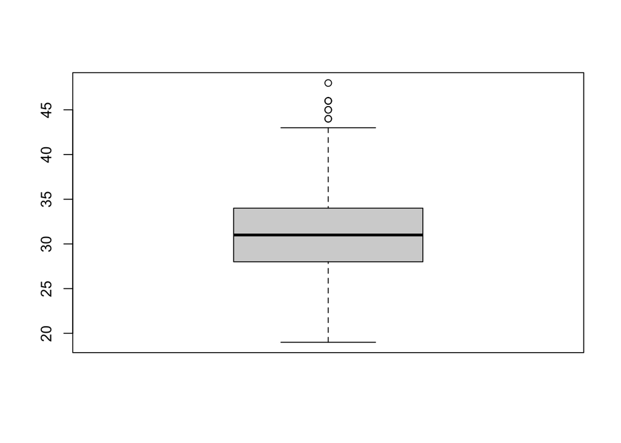

```r
boxplot(ufc$R_Age)
```

```r
boxplot.stats(ufc$R_Age)$out
```

```
## [1] 45 45 46 46 46 48 44 44
```

En este ejemplo, podemos ver como se consideran atípicos valores perfectamente validos. Crearemos una función para estudiar los valores que se consideran atípicos.

```r
detect_outliers <- function(x){
  quantiles <- quantile(x, c(0, 1), na.rm = TRUE)

  min_atipico = quantiles[1]-quantiles[1]*0.05
  max_atipico = quantiles[2]+quantiles[2]*0.05

  min_atipico = round(as.numeric(min_atipico),0)
  max_atipico = round(as.numeric(max_atipico),0)

  print(paste("Se reconoceran como valores atípicos aquellos que sean menores a", min_atipico, "y mayores a", max_atipico))
}
```

```r
print("Para la variable R_Age")
```

```
## [1] "Para la variable R_Age"
```

```r
detect_outliers(ufc$R_Age)
```

```
## [1] "Se reconoceran como valores atípicos aquellos que sean menores a 18 y mayores a 50"
```

```r
print("Para la variable BPrev")
```

```
## [1] "Para la variable BPrev"
```

```r
detect_outliers(ufc$BPrev)
```

```
## [1] "Se reconoceran como valores atípicos aquellos que sean menores a 0 y mayores a 15"
```

```r
print("Para la variable BStreak")
```

```
## [1] "Para la variable BStreak"
```

```r
detect_outliers(ufc$BStreak)
```

```
## [1] "Se reconoceran como valores atípicos aquellos que sean menores a 0 y mayores a 10"
```

```r
print("Para la variable B_Age")
```

```
## [1] "Para la variable B_Age"
```

```r
detect_outliers(ufc$B_Age)
```

```
## [1] "Se reconoceran como valores atípicos aquellos que sean menores a 19 y mayores a 50"
```

```r
print("Para la variable B_Height")
```

```
## [1] "Para la variable B_Height"
```

```r
detect_outliers(ufc$B_Height)
```

```
## [1] "Se reconoceran como valores atípicos aquellos que sean menores a 144 y mayores a 224"
```

```r
print("Para la variable B_ID")
```

```
## [1] "Para la variable B_ID"
```

```r
detect_outliers(ufc$B_ID)
```

```
## [1] "Se reconoceran como valores atípicos aquellos que sean menores a 123 y mayores a 3356"
```

```r
print("Para la variable B_Weight")
```

```
## [1] "Para la variable B_Weight"
```

```r
detect_outliers(ufc$B_Weight)
```

```
## [1] "Se reconoceran como valores atípicos aquellos que sean menores a 49 y mayores a 126"
```

```r
print("Para la variable Last_round")
```

```
## [1] "Para la variable Last_round"
```

```r
detect_outliers(ufc$Last_round)
```

```
## [1] "Se reconoceran como valores atípicos aquellos que sean menores a 1 y mayores a 5"
```

```r
print("Para la variable Max_round")
```

```
## [1] "Para la variable Max_round"
```

```r
detect_outliers(ufc$Max_round)
```

```
## [1] "Se reconoceran como valores atípicos aquellos que sean menores a 3 y mayores a 5"
```

```r
print("Para la variable RPrev")
```

```
## [1] "Para la variable RPrev"
```

```r
detect_outliers(ufc$RPrev)
```

```
## [1] "Se reconoceran como valores atípicos aquellos que sean menores a 0 y mayores a 17"
```

```r
print("Para la variable R_Age")
```

```
## [1] "Para la variable R_Age"
```

```r
detect_outliers(ufc$R_Age)
```

```
## [1] "Se reconoceran como valores atípicos aquellos que sean menores a 18 y mayores a 50"
```

```r
print("Para la variable R_Height")
```

```
## [1] "Para la variable R_Height"
```

```r
detect_outliers(ufc$R_Height)
```

```
## [1] "Se reconoceran como valores atípicos aquellos que sean menores a 144 y mayores a 224"
```

```r
print("Para la variable R_Weight")
```

```
## [1] "Para la variable R_Weight"
```

```r
detect_outliers(ufc$R_Weight)
```

```
## [1] "Se reconoceran como valores atípicos aquellos que sean menores a 49 y mayores a 126"
```

Tras estos resultados, vamos a eliminar los valores atípicos de aquellas variables que realmente puedan ser valores erróneos. Crearemos una función para ello.

```r
impute_outliers <- function(x){
  quantiles <- quantile(x, c(0, 1), na.rm = TRUE)

  min_atipico = quantiles[1]-quantiles[1]*0.05

  max_atipico = quantiles[2]+quantiles[2]*0.05

  min_atipico = round(as.numeric(min_atipico),0)
  max_atipico = round(as.numeric(max_atipico),0)

  x[x<min_atipico]<-NA
  x[x>max_atipico]<-NA

  return(x)
}
```

```r
ufc$BPrev<-impute_outliers(ufc$BPrev)
ufc$BStreak<-impute_outliers(ufc$BStreak)
ufc$B_Height<-impute_outliers(ufc$B_Height)
ufc$B_ID<-impute_outliers(ufc$B_ID)
ufc$B_Weight<-impute_outliers(ufc$B_Weight)
ufc$Last_round<-impute_outliers(ufc$Last_round)
ufc$Max_round<-impute_outliers(ufc$Max_round)
ufc$RPrev<-impute_outliers(ufc$RPrev)
ufc$R_Height<-impute_outliers(ufc$R_Height)
ufc$R_Weight<-impute_outliers(ufc$R_Weight)

colSums(is.na(ufc) | ufc=="")
```

```
##      BPrev    BStreak      B_Age   B_Height B_HomeTown       B_ID B_Location
##          0          0          0          0          0          0          0
##     B_Name   B_Weight       Date   Event_ID   Fight_ID Last_round  Max_round
##          0          0          0          0          0          0          0
##      RPrev      R_Age   R_Height R_HomeTown       R_ID R_Location     R_Name
##          0          0          0          0          0          0          0
##   R_Weight      winby     winner       year max_year_b max_year_r
##          0          0          0          0          0          0
```

Hemos puesto los valores atípicos a NaN, y podemos ver que no teníamos ningún valor atípico.

### 2.3.5 Exportación de los datos preprocesados

Una vez hemos llevado a cabo la integración, validación y limpieza el dataset, exportaremos los datos a csv como un nuevo fichero llamado *ufc-cleaned.csv*

```r
write.csv(ufc, "../data/ufc-cleaned.csv")
```

## 2.4 Análisis de los datos

### 2.4.1 Selección de los grupos de datos

En este apartado seleccionaremos los grupos dentro de nuestro dataset que pueden resultar relevantes para el análisis y comparación.

En nuestro caso, haremos grupos según el peso de los luchadores de los ganadores de cada pelea.

```r
ufc_blue_winner <- ufc[ufc$winner=="blue",]
ufc_red_winner <- ufc[ufc$winner=="red",]
# Agrupación por pesos segun el ganador
ufc.peso_medio_azul<-ufc_blue_winner[ufc_blue_winner$B_Weight<=83,]
ufc.peso_semipesado_azul<-ufc_blue_winner[ufc_blue_winner$B_Weight>83 & ufc_blue_winner$B_Weight<=93,]
ufc.peso_pesado_azul<-ufc_blue_winner[ufc_blue_winner$B_Weight>93 & ufc_blue_winner$B_Weight<=120,]

ufc.peso_medio_rojo<-ufc_red_winner[ufc_red_winner$R_Weight<=83,]
ufc.peso_semipesado_rojo<-ufc_red_winner[ufc_red_winner$R_Weight>83 & ufc_red_winner$R_Weight<=93,]
ufc.peso_pesado_rojo<-ufc_red_winner[ufc_red_winner$R_Weight>93 & ufc_red_winner$R_Weight<=120,]
```

### 2.4.2 Comprobación de la normalidad y homogeneidad de la varianza.

```r
library(nortest)

alpha = 0.05
ufc_numeric<-select_if(ufc, is.numeric)
col.names =colnames(ufc_numeric)

for (i in 1:ncol(ufc_numeric)) {
  p_val <- shapiro.test(unlist(ufc_numeric[,i]))$p.value

  if (p_val < alpha) message <- "NO sigue una distribución normal"
  else message <- "sigue una distribución normal"

  print(paste("La variable",col.names[i],"ha obtenido un p-value de",p_val,"por lo tanto",message))
}
```

```
## [1] "La variable BPrev ha obtenido un p-value de 2.16624245269375e-42 por lo tanto NO sigue una distribución normal"
## [1] "La variable BStreak ha obtenido un p-value de 2.84857722024883e-54 por lo tanto NO sigue una distribución normal"
## [1] "La variable B_Age ha obtenido un p-value de 0.000000000000026966231693912 por lo tanto NO sigue una distribución normal"
## [1] "La variable B_Height ha obtenido un p-value de 0.000000000000364464087805465 por lo tanto NO sigue una distribución normal"
## [1] "La variable B_ID ha obtenido un p-value de 9.47944428793231e-37 por lo tanto NO sigue una distribución normal"
## [1] "La variable B_Weight ha obtenido un p-value de 3.11216184146104e-35 por lo tanto NO sigue una distribución normal"
## [1] "La variable Event_ID ha obtenido un p-value de 0.00000000000000000000000000241928208264067 por lo tanto NO sigue una distribución normal"
## [1] "La variable Fight_ID ha obtenido un p-value de 0.000000000000000000000000000301087197455054 por lo tanto NO sigue una distribución normal"
## [1] "La variable Last_round ha obtenido un p-value de 7.35628744791904e-48 por lo tanto NO sigue una distribución normal"
## [1] "La variable Max_round ha obtenido un p-value de 7.29017004415995e-68 por lo tanto NO sigue una distribución normal"
## [1] "La variable RPrev ha obtenido un p-value de 4.74572224689499e-38 por lo tanto NO sigue una distribución normal"
## [1] "La variable R_Age ha obtenido un p-value de 0.00000000788299757747972 por lo tanto NO sigue una distribución normal"
## [1] "La variable R_Height ha obtenido un p-value de 0.000000000000013831298216037 por lo tanto NO sigue una distribución normal"
## [1] "La variable R_ID ha obtenido un p-value de 0.0000000000000000000000000000000576282212380446 por lo tanto NO sigue una distribución normal"
## [1] "La variable R_Weight ha obtenido un p-value de 2.34603342583551e-35 por lo tanto NO sigue una distribución normal"
## [1] "La variable year ha obtenido un p-value de 3.79032548096337e-37 por lo tanto NO sigue una distribución normal"
## [1] "La variable max_year_b ha obtenido un p-value de 7.28956990182894e-46 por lo tanto NO sigue una distribución normal"
## [1] "La variable max_year_r ha obtenido un p-value de 3.57777846157806e-50 por lo tanto NO sigue una distribución normal"
```

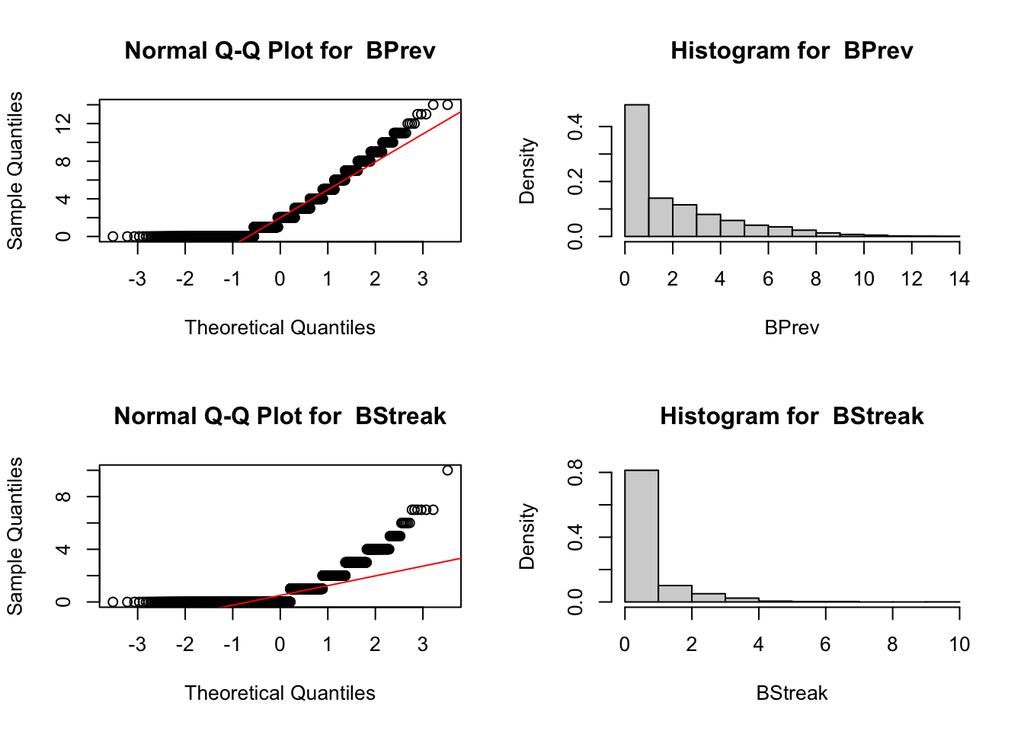

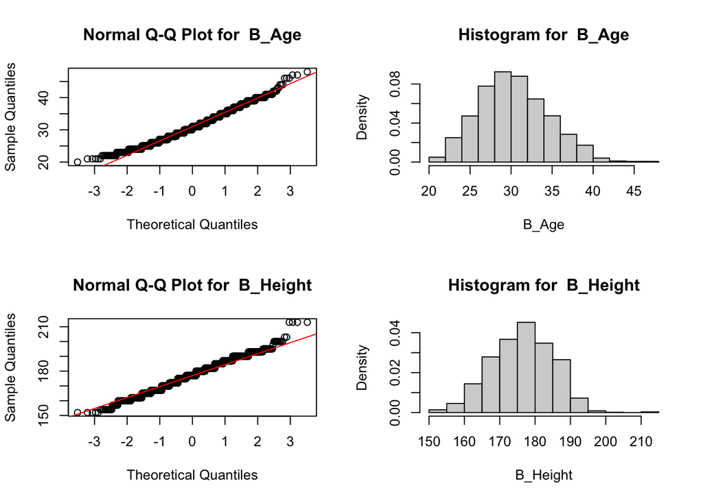

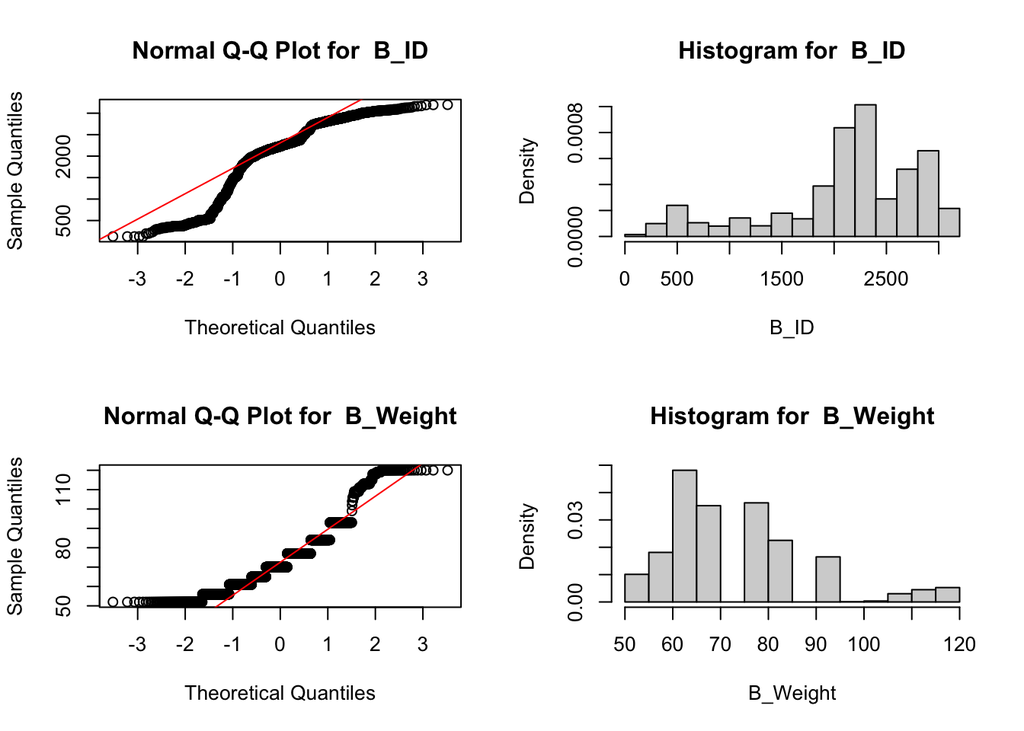

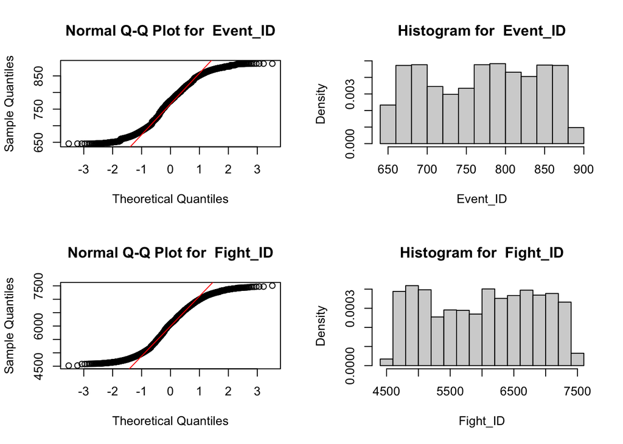

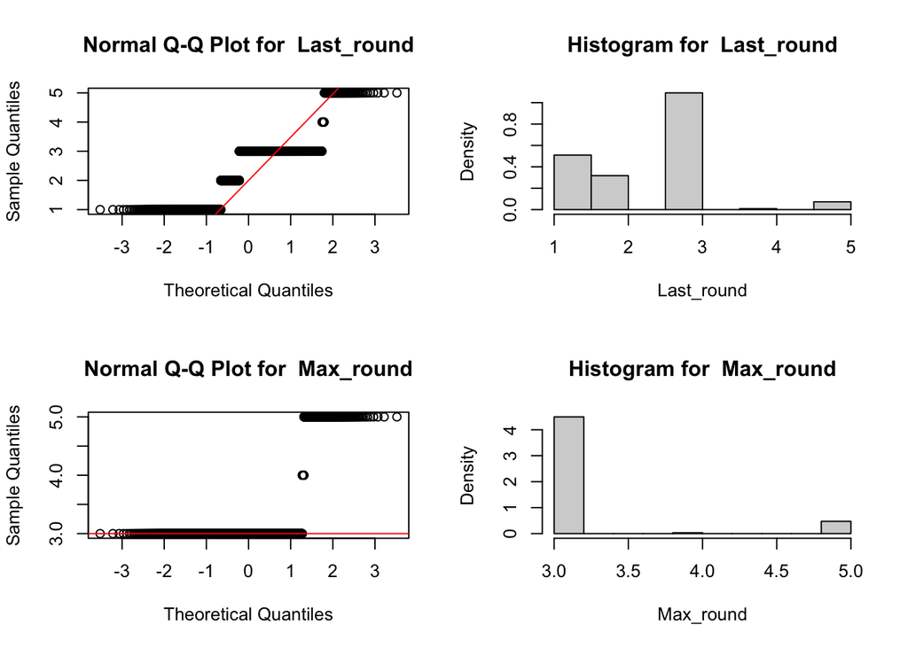

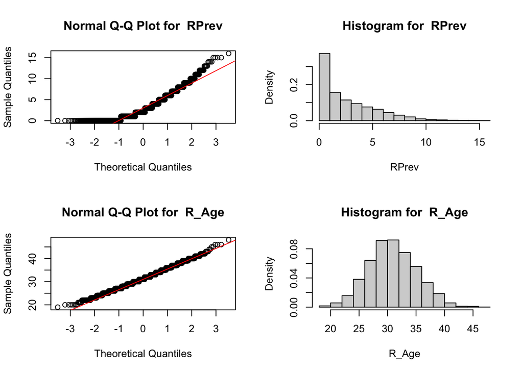

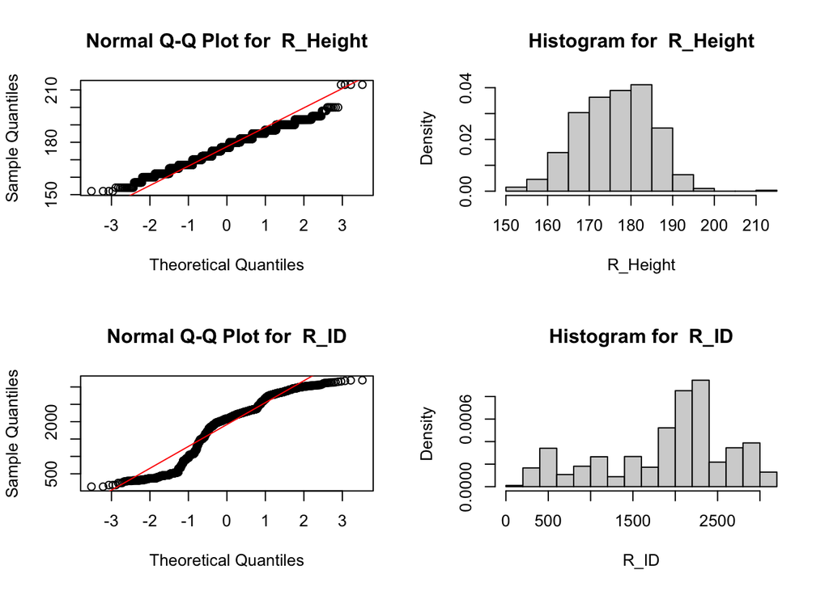

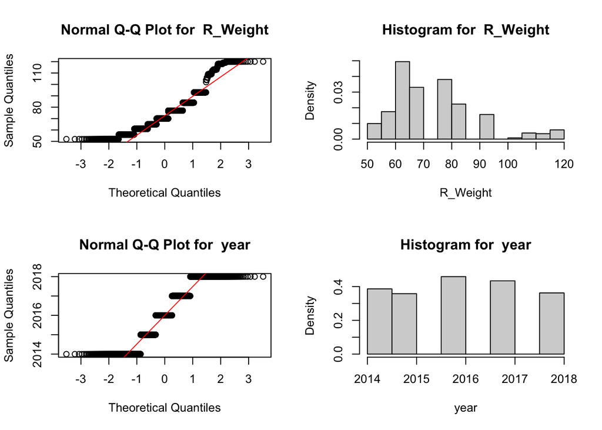

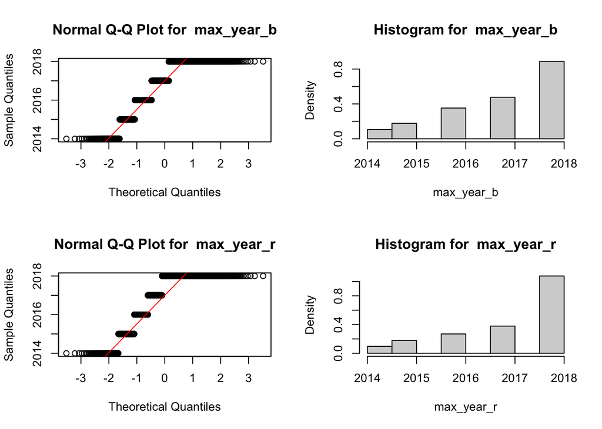

```r
par(mfrow=c(2,2))
for(i in 1:ncol(ufc_numeric)) {
  col<-unlist(ufc_numeric[,i])
  qqnorm(col, main = paste("Normal Q-Q Plot for ",colnames(ufc_numeric)[i]))
  qqline(col,col="red")
  hist(col, main=paste("Histogram for ", colnames(ufc_numeric)[i]), xlab=colnames(ufc_numeric)[i], freq = FALSE)
}
```

```r
ufc_homogeniedad = cbind(ufc,class.ind(unlist(ufc[,c("winner")])))
```

Una vez hemos incorporado las columnas necesarias para transformar la variable categórica *winner* en variable numérica, podemos proceder a realizar el test.

```r
resLevene<-leveneTest(y = ufc_homogeniedad$blue, group = ufc_homogeniedad$B_Age, center = "median")
```

### 2.4.3 Pruebas estadísticas

Como primer paso, debemos saber que variables son las mas influyentes sobre el ganador, esto lo haremos estudiando la correlación entre las variables.

#### 2.4.3.1 Correlación entre las variables

```r
newUfc<-cbind(ufc_numeric,class.ind(unlist(ufc[,c("winner")])))

mycor = cor(newUfc, method = "spearman" , use = "complete.obs")
mycor
```

```
##                  BPrev      BStreak        B_Age     B_Height        B_ID
## BPrev       1.00000000  0.522728637  0.114434735  0.053980088 -0.29221118
## BStreak     0.52272864  1.000000000 -0.033937690  0.022728892 -0.12644279
## B_Age       0.11443473 -0.033937690  1.000000000  0.086267646 -0.47260621
## B_Height    0.05398009  0.022728892  0.086267646  1.000000000 -0.07931321
## B_ID       -0.29221118 -0.126442791 -0.472606208 -0.079313208  1.00000000
## B_Weight    0.07561756  0.026000686  0.192420732  0.867375056 -0.15968822
## Event_ID    0.44625845  0.179269837 -0.151469598 -0.019336854  0.45897361
## Fight_ID    0.43816345  0.170001129 -0.156396744 -0.024804106  0.46921300
## Last_round  0.04836089  0.054175230  0.010457533 -0.137699035 -0.01794874
## Max_round   0.11493450  0.182224885  0.122674594  0.022653346 -0.23873329
## RPrev       0.58380117  0.331869580 -0.007074449  0.031779123  0.02458633
## R_Age       0.10914581  0.024039049  0.114158711  0.202034861 -0.20793299
## R_Height    0.03764299  0.014446597  0.162124801  0.750772387 -0.11558904
## R_ID       -0.17307945 -0.150279680 -0.241356016 -0.127027353  0.56345872
## R_Weight    0.05706269  0.017667145  0.193663562  0.843391905 -0.15539598
## year        0.39377423  0.147319623 -0.117810379 -0.016023227  0.43518960
## max_year_b  0.25987031  0.182149338 -0.352921042  0.031789222  0.28267630
## max_year_r  0.26903743  0.185036085 -0.017960446 -0.058093449  0.15055822
## blue        0.04308122  0.030193606 -0.180839796  0.018625689  0.05353292
## draw       -0.01931360 -0.003226879 -0.005218690  0.002160987  0.03217162
## no contest -0.02836966 -0.003331432  0.021198666  0.003963319 -0.05120408
## red        -0.03379716 -0.028798765  0.176338598 -0.019691468 -0.04813308
##                B_Weight     Event_ID     Fight_ID   Last_round    Max_round
## BPrev       0.075617557  0.446258453  0.438163448  0.048360893  0.114934496
## BStreak     0.026000686  0.179269837  0.170001129  0.054175230  0.182224885
## B_Age       0.192420732 -0.151469598 -0.156396744  0.010457533  0.122674594
## B_Height    0.867375056 -0.019336854 -0.024804106 -0.137699035  0.022653346
## B_ID       -0.159688221  0.458973614  0.469213002 -0.017948739 -0.238733288
## B_Weight    1.000000000 -0.033951498 -0.040240837 -0.133418675  0.071648308
## Event_ID   -0.033951498  1.000000000  0.998520230  0.006208219 -0.011376738
## Fight_ID   -0.040240837  0.998520230  1.000000000  0.005126346 -0.019608144
## Last_round -0.133418675  0.006208219  0.005126346  1.000000000  0.116006672
## Max_round   0.071648308 -0.011376738 -0.019608144  0.116006672  1.000000000
## RPrev       0.052714992  0.584172595  0.578992851  0.031836163  0.090083645
## R_Age       0.263031387 -0.070899089 -0.074338739 -0.010851902  0.065351989
## R_Height    0.848263413 -0.030726270 -0.035893064 -0.132573720  0.046843769
## R_ID       -0.196813248  0.350113322  0.358499682 -0.028096703 -0.233621670
## R_Weight    0.963856040 -0.040299510 -0.046599225 -0.138573746  0.076211986
## year       -0.027378018  0.921519723  0.922265542  0.001767535 -0.029568983
```

[output cut: 60 more lines]

```
## Fight_ID   -0.047232902 -0.046186711
## Last_round -0.071900533  0.031466520
## Max_round   0.008437532  0.040477780
## RPrev      -0.046224234 -0.010205093
## R_Age       0.055372420 -0.161927000
## R_Height    0.007414391  0.004032005
## R_ID       -0.030345425  0.009760852
## R_Weight    0.018271216 -0.007446757
## year       -0.031553327 -0.040609612
## max_year_b -0.027954609 -0.199729451
## max_year_r -0.044962166  0.183425399
## blue       -0.085312941 -0.965171824
## draw       -0.008527392 -0.096473040
## no contest  1.000000000 -0.118360706
## red        -0.118360706  1.000000000
```

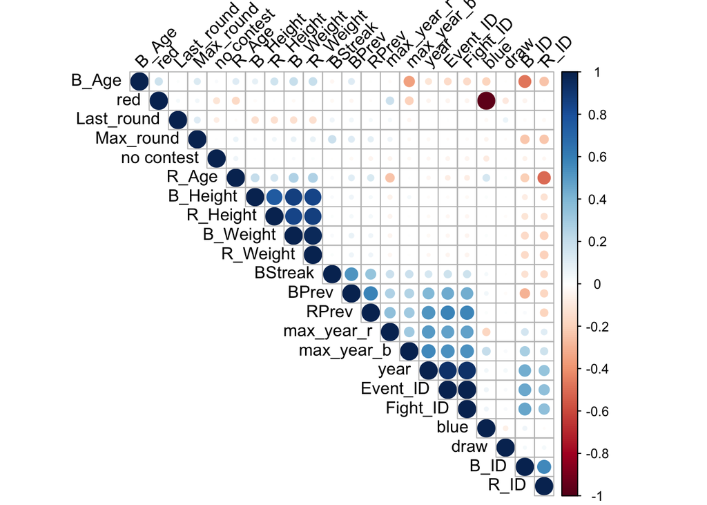

```r
corrplot(mycor, type = "upper", order = "hclust", tl.col = "black", tl.srt = 45)
```

Repetiremos este proceso con el Test de Sperman.

```r
Winby  = class.ind(unlist(ufc[,23]))
Winner = class.ind(unlist(ufc[,24]))

ufc_sperman<-cbind(ufc,Winby,Winner)

for (i in 1:(ncol(ufc_sperman))) {
  if (is.integer(ufc_sperman[,i]) | is.numeric(ufc_sperman[,i])) {
    spearman_test = cor.test(ufc_sperman[,i], ufc_sperman[,length(ufc_sperman)], method = "spearman", exact=FALSE)
    corr_coef = spearman_test$estimate
    print(paste("Para la variable",colnames(ufc_sperman)[i],"obtenemos una estimación de",corr_coef))
  }
}
```

```
## [1] "Para la variable BPrev obtenemos una estimación de -0.0337971555788443"
## [1] "Para la variable BStreak obtenemos una estimación de -0.0287987647114931"
## [1] "Para la variable B_Age obtenemos una estimación de 0.176338597777536"
## [1] "Para la variable B_Height obtenemos una estimación de -0.0196914679049064"
## [1] "Para la variable B_ID obtenemos una estimación de -0.0481330803769773"
## [1] "Para la variable B_Weight obtenemos una estimación de -0.0207364685224732"
## [1] "Para la variable Event_ID obtenemos una estimación de -0.0467405006274044"
## [1] "Para la variable Fight_ID obtenemos una estimación de -0.0461867110721585"
## [1] "Para la variable Last_round obtenemos una estimación de 0.0314665200460323"
## [1] "Para la variable Max_round obtenemos una estimación de 0.0404777802685008"
## [1] "Para la variable RPrev obtenemos una estimación de -0.0102050933310086"
## [1] "Para la variable R_Age obtenemos una estimación de -0.161926999861099"
## [1] "Para la variable R_Height obtenemos una estimación de 0.0040320052006182"
## [1] "Para la variable R_ID obtenemos una estimación de 0.00976085244782177"
## [1] "Para la variable R_Weight obtenemos una estimación de -0.0074467573251028"
## [1] "Para la variable year obtenemos una estimación de -0.0406096118076274"
## [1] "Para la variable max_year_b obtenemos una estimación de -0.199729451030299"
## [1] "Para la variable max_year_r obtenemos una estimación de 0.183425399296832"
## [1] "Para la variable DEC obtenemos una estimación de 0.01018262274043"
## [1] "Para la variable DRAW obtenemos una estimación de -0.0964730404234197"
## [1] "Para la variable KO/TKO obtenemos una estimación de -0.0137336554870595"
## [1] "Para la variable NO CONTEST obtenemos una estimación de -0.118360706348614"
## [1] "Para la variable SUB obtenemos una estimación de 0.0551725059029261"
## [1] "Para la variable blue obtenemos una estimación de -0.965171824430962"
## [1] "Para la variable draw obtenemos una estimación de -0.0964730404234197"
## [1] "Para la variable no contest obtenemos una estimación de -0.118360706348614"
## [1] "Para la variable red obtenemos una estimación de 1"
```

#### 2.4.3.2 ¿Hay categorias de peso con mas probabilidad de ganador?

Si recuperamos los grupos hechos anteriormente podemos utilizar el T-test para lograr decidir frente a nuestra hipótesis. Teniendo en cuenta que la hipótesis alternativa es que la categoría del peso influye en la victoria.

```r
ufc$winner_weight<-ifelse(ufc$winner=="blue",ufc$B_Weight,ufc$R_Weight)
ufc$winner_category<-ifelse(ufc$winner_weight<=83,1,
                            ifelse(ufc$winner_weight>83 & ufc$winner_weight<=93, 2,
                                   ifelse(ufc$winner_weight>93 & ufc$winner_weight<=140, 3,0)))

t.test(class.ind(ufc$winner), ufc$winner_category,alternative = "less")
```

```
##
##  Welch Two Sample t-test
##
## data:  class.ind(ufc$winner) and ufc$winner_category
## t = -81.588, df = 2948.5, p-value < 0.00000000000000022
## alternative hypothesis: true difference in means is less than 0
## 95 percent confidence interval:
##       -Inf -1.058245
## sample estimates:
## mean of x mean of y
##  0.250000  1.330026
```

Dado que hemos obtenido un p-value menor que 0.05, rechazamos la hipótesis nula. Esto quiere decir que el la categoría en la que se encuentra el luchador influye en la victoria.

#### 2.4.3.3 ¿Podemos averiguar el ganador teniendo su peso, su altura y su edad y el de su contrincante?

Para el siguiente apartado, emplearemos una regresión lineal para generar un modelo y predecir los resultados de un combate ficticio. Primero genereremos el modelo utilizando la funcion *lm*

```r
ufc$winner_numerical<-ifelse(ufc$winner=="blue",1,2)
ufc_model<-lm(winner_numerical ~ winner_category + B_Height + R_Height + B_Age + R_Age, data = ufc)
ufc_model
```

```
##
## Call:
## lm(formula = winner_numerical ~ winner_category + B_Height +
##     R_Height + B_Age + R_Age, data = ufc)
##
## Coefficients:
##     (Intercept)  winner_category         B_Height         R_Height
##       1.5886473        0.0022458        0.0007437       -0.0010879
##           B_Age            R_Age
##       0.0232742       -0.0209995
```

Una vez generado el modelo crearemos un combate ficticio

```r
new<-data_frame(winner_category=c(2),B_Height=c(181),R_Height=c(169),B_Age=c(25),R_Age=c(34))
new
```

```
## # A tibble: 1 x 5
##   winner_category B_Height R_Height B_Age R_Age
##             <dbl>    <dbl>    <dbl> <dbl> <dbl>
## 1               2      181      169    25    34
```

Ahora aplicaremos el modelo con el nuevo combate y veremos el resultado que nos da.

```r
round(predict(ufc_model, new),0)
```

```
## 1
## 1
```

Tras aplicar la predicción, obtenemos el resultado de que el ganador seria el azul, si paramos a pensarlo, tiene cierta ventaja ya que es más alto y se encuentra en una edad mas energética.

### 2.4.4 Visualización de los datos

Vamos analizar los datos de nuestro dataset para analizar las caracteristicas de nuestros combatientes y analizar sus victorias.

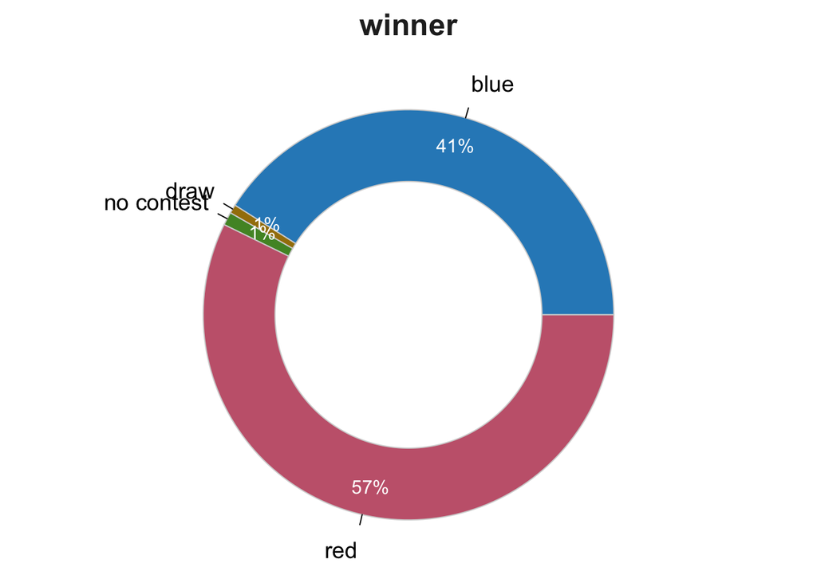

```
## >>> Suggestions
## PieChart(winner, hole=0)  # traditional pie chart
## PieChart(winner, values="%")  # display %'s on the chart
## BarChart(winner)  # bar chart
## Plot(winner)  # bubble plot
## Plot(winner, values="count")  # lollipop plot
##
##
## --- winner ---
##
##
##                 blue   draw  no contest    red      Total
## Frequencies:     951     16          24   1327       2318
## Proportions:   0.410  0.007       0.010  0.572      1.000
##
##
## Chi-squared test of null hypothesis of equal probabilities
##   Chisq = 2282.797, df = 3, p-value = 0.000
```

```r
PieChart(winner,data = ufc)
```

Observamos que hay mas combatientes ganadores rojos que azules, vamos analizar si la edad es influyente es las victorias o no.

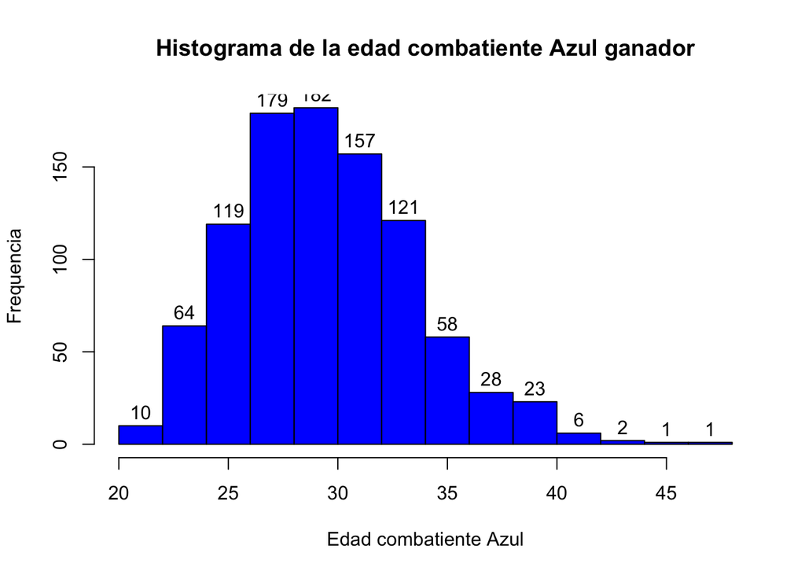

```r
ufc_blue_winner <- ufc[ufc$winner=="blue",]
ufc_red_winner <- ufc[ufc$winner=="red",]

hist(ufc_blue_winner$B_Age,
    col="blue",
    main="Histograma de la edad combatiente Azul ganador",
    xlab="Edad combatiente Azul",
    ylab="Frequencia",
    labels=TRUE)
```

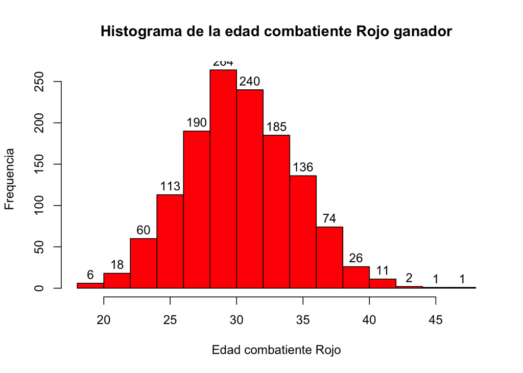

```r
hist(ufc_red_winner$R_Age,
    col="red",
    main="Histograma de la edad combatiente Rojo ganador",
    xlab="Edad combatiente Rojo",
    ylab="Frequencia",
    labels=TRUE)
```

Observamos a simple vista que los combatientes Azules ganadores son mas jovenes que los ganadores rojos, viendo que el pico de ganadores esta entorno a los 30 años en los dos casos.

Vemos como influye ahora la altura a nuestros ganadores.

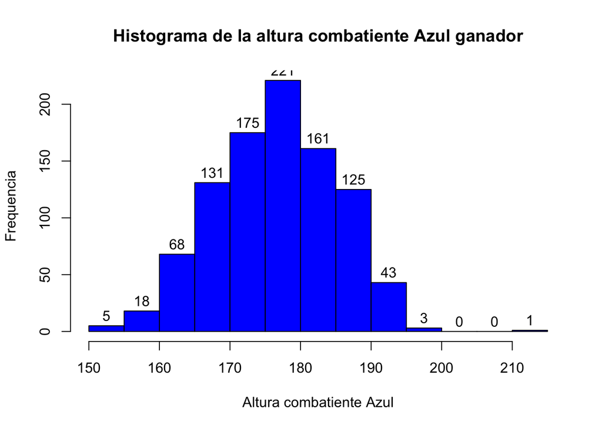

```r
hist(ufc_blue_winner$B_Height,
    col="blue",
    main="Histograma de la altura combatiente Azul ganador",
    xlab="Altura combatiente Azul",
    ylab="Frequencia",
    labels=TRUE)
```

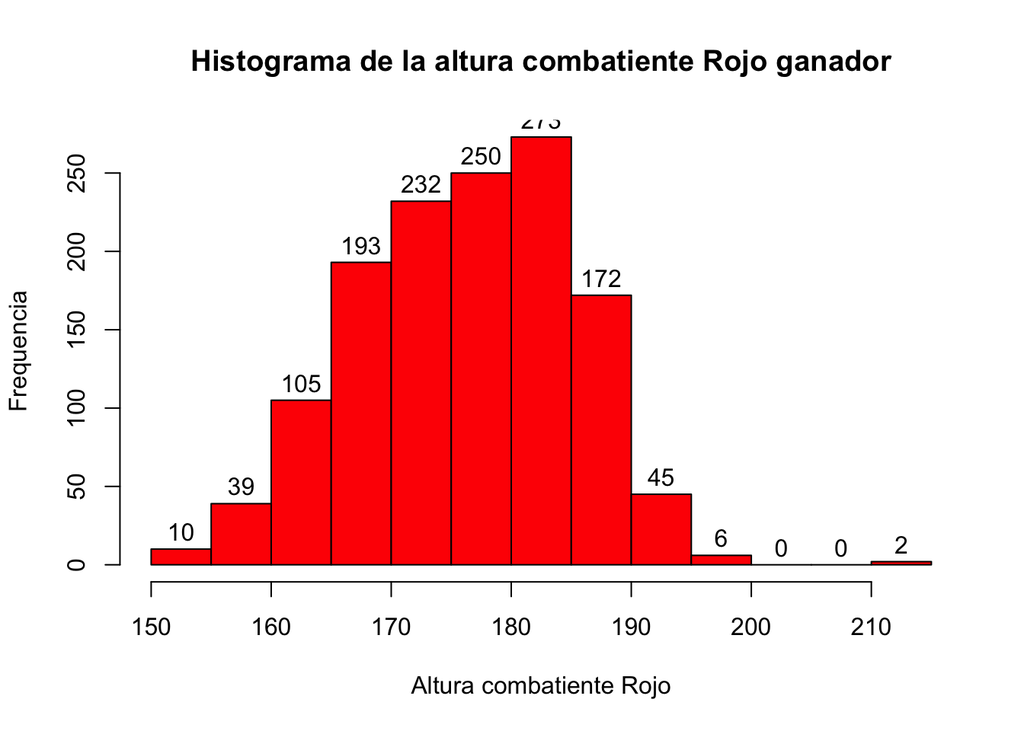

```r
hist(ufc_red_winner$R_Height,
    col="red",
    main="Histograma de la altura combatiente Rojo ganador",
    xlab="Altura combatiente Rojo",
    ylab="Frequencia",
    labels=TRUE)
```

Observamos también que los combatientes del lado rojo suelen ser un poco mas altos que los ganadores azules.

El peso en los combates no es influyente para la victoria porque pactan el peso en el que van a pelear así que esta columna no la observaremos.

Vamos a observar como son las victorias de nuestros combatientes.

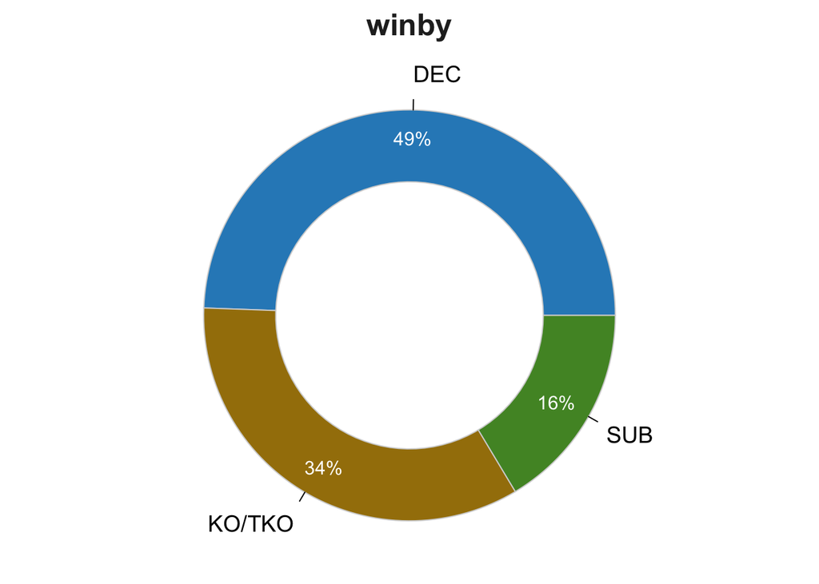

```
## >>> Suggestions
## PieChart(winby, hole=0)  # traditional pie chart
## PieChart(winby, values="%")  # display %'s on the chart
## BarChart(winby)  # bar chart
## Plot(winby)  # bubble plot
## Plot(winby, values="count")  # lollipop plot
##
##
## --- winby ---
##
##
##                  DEC  KO/TKO    SUB     Total
## Frequencies:     470     325    156       951
## Proportions:   0.494   0.342  0.164     1.000
##
##
## Chi-squared test of null hypothesis of equal probabilities
##   Chisq = 155.817, df = 2, p-value = 0.000
```

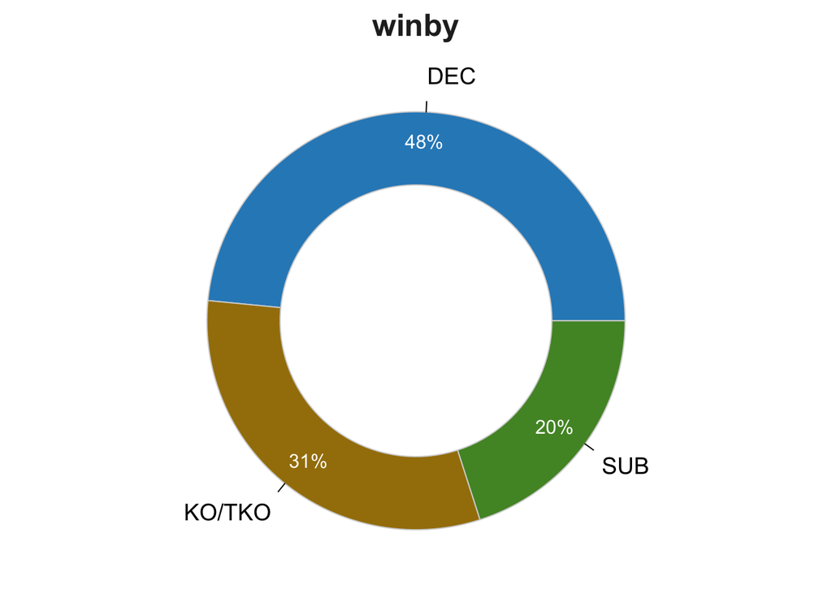

```
## >>> Suggestions
## PieChart(winby, hole=0)  # traditional pie chart
## PieChart(winby, values="%")  # display %'s on the chart
## BarChart(winby)  # bar chart
## Plot(winby)  # bubble plot
## Plot(winby, values="count")  # lollipop plot
##
##
## --- winby ---
##
##
##                  DEC  KO/TKO    SUB      Total
## Frequencies:     643     418    266       1327
## Proportions:   0.485   0.315  0.200      1.000
##
##
## Chi-squared test of null hypothesis of equal probabilities
##   Chisq = 162.666, df = 2, p-value = 0.000
```

Observamos que en los dos casos las maneras de ganar de los dos lados son muy parecidas.

### 2.4.5 Conclusiones

Tras la realización de estos tres test hemos podido observar que con el conjunto de datos actuales hay poca información para obtener conclusiónes suficientemente solidas como para apostar, esto es debido a que hemos obtenido un subgrupo de las variables iniciales, ya que con mucha seguridad trabajando con las 894 variables podríamos obtener resultados mucho más precisos, pero son un numero de variables muy grande y hemos intentado utilizar menos variables.

En la limpieza hemos visto cosas que hasta ahora no habíamos visto, así como los diferentes formatos de fecha y la edad estática. Gracias al problema de la edad estática hemos podido comprender que es mucho mejor conocer sobre el tema que se esta tratando para poder utilizar la información ajena a la matemática y la estadística, como cuando necesitas saber en que categoría compite cada uno de ellos según el peso.

| Contribuciones | Firma |
| --- | --- |
| Investigación previa | IA, AH |
| Redacción de las respuestas | IA, AH |
| Desarrollo código | IA, AH |